```python
import pandas as pd
from matplotlib import pyplot as plt
import seaborn as sns
from sklearn.compose import ColumnTransformer
from sklearn.preprocessing import StandardScaler, OneHotEncoder
from imblearn.over_sampling import SMOTE
from sklearn.model_selection import train_test_split
from sklearn.linear_model import LogisticRegression
from sklearn.ensemble import RandomForestClassifier
from sklearn.tree import DecisionTreeClassifier
from xgboost import XGBClassifier
from sklearn.preprocessing import LabelEncoder
from sklearn.neighbors import KNeighborsClassifier
from sklearn.model_selection import GridSearchCV
from sklearn.metrics import accuracy_score, confusion_matrix, classification_report
```

# **Problem Statement**

As the newly hired data Data scientist at digital music industry company "Spotify", my task is to help marketing department by analyzing the dataset. I will build a structured pipeline to predict the ouctome of users swithing to paid premium subscription. This is a pivotal objective for a company, as it will greatly benefit to the growth of revenue and aid in maintaining competitiveness. The given dataset will provide me a vast background on users' data such as their age, gender, usage period and etc. This task is binary classification machine learning problem, where there are two choices: YES or NO. In order to complete this mission, I will go through various processes including- data collection, exploration, preprocessing, feature engineering, model training, and finally model assessment. By the end of this notebook, marketing department will have a clear insight on how to proceed with their business startegies.

# **Data** **Collection**

The code belows give us an insight on first rows of dataset

```python
df = pd.read_csv("Spotify_data.csv")
df.head()
```

|  | Age | Gender | spotify_usage_period | spotify_listening_device | spotify_subscription_plan | premium_sub_willingness | preffered_premium_plan | preferred_listening_content | fav_music_genre | music_time_slot | music_Influencial_mood | music_lis_frequency | music_expl_method | music_recc_rating | pod_lis_frequency | fav_pod_genre | preffered_pod_format | pod_host_preference | preffered_pod_duration | pod_variety_satisfaction |
| --- | --- | --- | --- | --- | --- | --- | --- | --- | --- | --- | --- | --- | --- | --- | --- | --- | --- | --- | --- | --- |
| 0 | 20-35 | Female | More than 2 years | Smart speakers or voice assistants | Free (ad-supported) | Yes | Family Plan-Rs 179/month | Podcast | Melody | Night | Sadness or melancholy | leisure time | Playlists | 3 | Daily | Comedy | Interview | Both | Both | Ok |
| 1 | 12-20 | Male | More than 2 years | Computer or laptop | Free (ad-supported) | Yes | Individual Plan- Rs 119/ month | Podcast | Rap | Afternoon | Social gatherings or parties | Workout session | Playlists | 2 | Several times a week | Comedy | Interview | Both | NaN | Satisfied |
| 2 | 35-60 | Others | 6 months to 1 year | Smart speakers or voice assistants | Free (ad-supported) | Yes | Student Plan-Rs 59/month | Podcast | Pop | Night | Relaxation and stress relief | Study Hours, While Traveling | Playlists | 4 | Once a week | Sports | Interview | NaN | Both | Satisfied |
| 3 | 20-35 | Female | 1 year to 2 years | Smartphone, Smart speakers or voice assistants | Free (ad-supported) | No | NaN | Music | Melody | Night | Relaxation and stress relief, Social gathering... | Office hours, Workout session, leisure time | recommendations, Playlists | 4 | Never | NaN | NaN | NaN | NaN | Ok |
| 4 | 20-35 | Female | 1 year to 2 years | Smartphone | Free (ad-supported) | No | NaN | Music | Melody | Night | Relaxation and stress relief | leisure time | recommendations, Playlists | 4 | Rarely | Lifestyle and Health | Story telling | Well known individuals | Both | Ok |

# **Data Exploration**

Here we can see that all features except for music_recc_rating are objects. Age and spotify_usage_period are not considered inegers.

```python
df.dtypes
```

```
Age                            object
Gender                         object
spotify_usage_period           object
spotify_listening_device       object
spotify_subscription_plan      object
premium_sub_willingness        object
preffered_premium_plan         object
preferred_listening_content    object
fav_music_genre                object
music_time_slot                object
music_Influencial_mood         object
music_lis_frequency            object
music_expl_method              object
music_recc_rating               int64
pod_lis_frequency              object
fav_pod_genre                  object
preffered_pod_format           object
pod_host_preference            object
preffered_pod_duration         object
pod_variety_satisfaction       object
dtype: object
```

df.columns and df.describe show all columns and some info on count.

```python
print(df.columns)
print(df.describe())
```

```
Index(['Age', 'Gender', 'spotify_usage_period', 'spotify_listening_device',
       'spotify_subscription_plan', 'premium_sub_willingness',
       'preffered_premium_plan', 'preferred_listening_content',
       'fav_music_genre', 'music_time_slot', 'music_Influencial_mood',
       'music_lis_frequency', 'music_expl_method', 'music_recc_rating',
       'pod_lis_frequency', 'fav_pod_genre', 'preffered_pod_format',
       'pod_host_preference', 'preffered_pod_duration',
       'pod_variety_satisfaction'],
      dtype='object')
       music_recc_rating
count         520.000000
mean            3.503846
std             0.979552
min             1.000000
25%             3.000000
50%             3.500000
75%             4.000000
max             5.000000
```

# **Data Preprocessing**

For data preprocessing, we initially check for missing values. preffered_premium_plan, fav_pod_genre, preffered_pod_format, pod_host_preference, preffered_pod_duration have missing values

```python
df.isnull().sum()
```

```
Age                              0
Gender                           0
spotify_usage_period             0
spotify_listening_device         0
spotify_subscription_plan        0
premium_sub_willingness          0
preffered_premium_plan         208
preferred_listening_content      0
fav_music_genre                  0
music_time_slot                  0
music_Influencial_mood           0
music_lis_frequency              0
music_expl_method                0
music_recc_rating                0
pod_lis_frequency                0
fav_pod_genre                  148
preffered_pod_format           140
pod_host_preference            141
preffered_pod_duration         129
pod_variety_satisfaction         0
dtype: int64
```

To mitigate that I use df.bfill(inplace=True) command. It is used to fill missing values with the next nonmissing values coming after it in the same column

```python
df.bfill(inplace=True)
```

```python
df.isnull().sum()
```

```
Age                            0
Gender                         0
spotify_usage_period           0
spotify_listening_device       0
spotify_subscription_plan      0
premium_sub_willingness        0
preffered_premium_plan         0
preferred_listening_content    0
fav_music_genre                0
music_time_slot                0
music_Influencial_mood         0
music_lis_frequency            0
music_expl_method              0
music_recc_rating              0
pod_lis_frequency              0
fav_pod_genre                  1
preffered_pod_format           1
pod_host_preference            1
preffered_pod_duration         1
pod_variety_satisfaction       0
dtype: int64
```

For some unkwon reason, there are still few values missing. One possibility is that there was not valid data to fill forward with

```python
df = df.dropna(axis=1)
```

Nevertheless, I decide to drop those with remaning values for clear data

```python
df.isnull().sum()
```

```
Age                            0
Gender                         0
spotify_usage_period           0
spotify_listening_device       0
spotify_subscription_plan      0
premium_sub_willingness        0
preffered_premium_plan         0
preferred_listening_content    0
fav_music_genre                0
music_time_slot                0
music_Influencial_mood         0
music_lis_frequency            0
music_expl_method              0
music_recc_rating              0
pod_lis_frequency              0
pod_variety_satisfaction       0
dtype: int64
```

After cleaning data, I seperate dataframe into X and Y features. Because premium_sub_willingness is my target I drop it from dataframe. Then I train_test_split to divide x and y into training and testing sets. Test size 0.2 means that 20% is reserved for test set and 80% for train set. random_state=42 helps to reproduce same result each time.

```python
X, y = df.drop("premium_sub_willingness", axis=1) , df["premium_sub_willingness"]
x_train, x_test, y_train, y_test = train_test_split(X, y, test_size=0.2, random_state=42)
print("df size:", df.shape)
print("df train size:", x_train.shape)
print("df test size:", x_test.shape)
```

```
df size: (520, 16)
df train size: (416, 15)
df test size: (104, 15)
```

The barchart below shows distibution of premium_sub_willingness

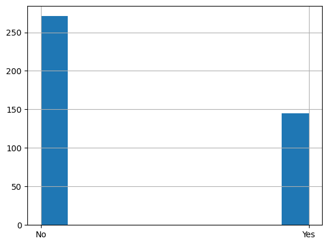

```python
y_train.hist()
```

Here I just print sizes for x_train y_train x_test y_test

```python
print("x_train size:", x_train.shape)
print("y_train size:", y_train.shape)
print("x_test size:", x_test.shape)
print("y_test size:", y_test.shape)
```

```
x_train size: (416, 15)
y_train size: (416,)
x_test size: (104, 15)
y_test size: (104,)
```

# **Feature Engineering**

For feature engineering, we firstly identify Numerical and Categorical Attributes from x_train dataset. After I use standarscaler for numerical feature the mean and scales the data to unit variance. This helps machine to behave better. Then I apply onehotencoding for categorical features to assit machine learning in predicting by transforming values into a more suitable format

```python
numerical_attributes = x_train.select_dtypes(include=["int64", "float64"]).columns
categorical_attributes = x_train.select_dtypes(include="object").columns

ct = ColumnTransformer([
    ("standard_scaling", StandardScaler(), numerical_attributes),
    ("one_hot_encoding", OneHotEncoder(handle_unknown="ignore"), categorical_attributes)
])

ct.fit(x_train)
x_train = ct.transform(x_train)
x_test = ct.transform(x_test)
print("x_train size:", x_train. shape)
print("x_test size:", x_test. shape)
```

```
x_train size: (416, 127)
x_test size: (104, 127)
```

In order to keep the classifier from being overpowered by the majority class, SMOTE is an oversampling technique that creates artificial samples from the minority class. It accomplishes that by chosing a random point from minority and then computing k-nearest neighbors for this point.

```python
smote = SMOTE(random_state=42)
x_train, y_train = smote.fit_resample(x_train, y_train)
```

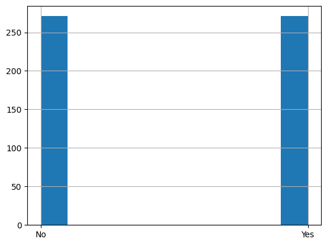

```python
y_train.hist()
```

As you can see the distrivution after smote is equal

# **Models Training And Evaluation**

Now I pick various machine learning models and train them to see which one performs the best. I applied the hyperparameter "GridSearchCV" for all of them to boost their perfomances. For parameterers I put cv=5 for 5-fold cross-validation, scoring='accuracy', and n_jobs=-1 to utilize all available cpu cores to speed up the search.

```python
dt = DecisionTreeClassifier(random_state=42)
param_grid = {
    'max_depth': [None, 3, 5, 10, 20],
    'min_samples_split': [2, 5, 10],
    'min_samples_leaf': [1, 2, 4]
}

grid_search = GridSearchCV(estimator=dt, param_grid=param_grid, cv=5, scoring='accuracy', n_jobs=-1)
grid_search.fit(x_train, y_train)

print(f"Best parameters: {grid_search.best_params_}")
print(f"Best accuracy score: {grid_search.best_score_}")
```

```
Best parameters: {'max_depth': 10, 'min_samples_leaf': 2, 'min_samples_split': 5}
Best accuracy score: 0.8156982670744138
```

decision tree is a model than can be used for classification and regression problem. It divides dataset my making decisions based on feature values thus making pure subsets. The values for max_depth, min_samples_split, min_samples_leaf were chosen as they were most suitable for my usecase. grid_search.fit(x_train, y_train) executes the grid search over the specified parameter grid. And at the end it machine prints out best parameters with best accuracy score.

```python
lr = LogisticRegression(random_state=42)
param_grid = {
    'C': [0.001, 0.01, 0.1, 1, 10],
    'solver': ['liblinear', 'lbfgs'],
}

grid_search = GridSearchCV(estimator=lr, param_grid=param_grid, cv=5, scoring='accuracy', n_jobs=-1)

grid_search.fit(x_train, y_train)

print(f"Best parameters: {grid_search.best_params_}")
print(f"Best accuracy score: {grid_search.best_score_}")
```

```
Best parameters: {'C': 10, 'solver': 'liblinear'}
Best accuracy score: 0.7805810397553516
```

Then I tried LogisticRegression which is a binary classification model and repeated the same process but with differenet param grids. 'C' inverses the strength of regulirization and solver just applies specific algorithms

```python
rf = RandomForestClassifier(random_state=42)

param_grid = {
    'n_estimators': [100, 200],
    'max_depth': [None, 10, 20],
    'min_samples_split': [2, 5]
}

grid_search = GridSearchCV(estimator=rf, param_grid=param_grid, cv=5, scoring='accuracy', n_jobs=-1)

grid_search.fit(x_train, y_train)

print(f"Best parameters: {grid_search.best_params_}")
print(f"Best accuracy score: {grid_search.best_score_}")

test_accuracy = accuracy_score(y_test, y_pred)
print(f"Test accuracy: {test_accuracy}")
conf_matrix = confusion_matrix(y_test, y_pred)
print("Confusion Matrix:")
print(conf_matrix)
class_report = classification_report(y_test, y_pred)
print("Classification Report:")
print(class_report)
```

```
Best parameters: {'max_depth': None, 'min_samples_split': 5, 'n_estimators': 100}
Best accuracy score: 0.8544852191641183
Test accuracy: 0.7403846153846154
Confusion Matrix:
[[53 10]
 [17 24]]
Classification Report:
              precision    recall  f1-score   support

          No       0.76      0.84      0.80        63
         Yes       0.71      0.59      0.64        41

    accuracy                           0.74       104
   macro avg       0.73      0.71      0.72       104
weighted avg       0.74      0.74      0.74       104
```

Random forest classification is a model which is very accurate and robust. I got the best scores using this model and got accuracy score for train set 85% and 74% for test set.

```python
label_encoder = LabelEncoder()
y_train_encoded = label_encoder.fit_transform(y_train)
xgb = XGBClassifier(random_state=42)

param_grid = {
    'n_estimators': [50, 100, 200],
    'learning_rate': [0.01, 0.1, 0.2],
    'max_depth': [3, 6, 9],
}

grid_search = GridSearchCV(estimator=xgb, param_grid=param_grid, cv=5, scoring='accuracy', n_jobs=-1, verbose=1)
grid_search.fit(x_train, y_train_encoded)

print(f"Best parameters: {grid_search.best_params_}")
print(f"Best accuracy score: {grid_search.best_score_}")
```

```
Fitting 5 folds for each of 27 candidates, totalling 135 fits
Best parameters: {'learning_rate': 0.1, 'max_depth': 9, 'n_estimators': 50}
Best accuracy score: 0.8434930343187224
```

Lasly I tried XGboost model. However, before training it I had to use label encoder to transform non-numerical values to numerical labels.

# **Conclusion**

In order to predict the willigness of spotify users to subscribe to premium subscription, all the necessay steps were executed to conclude the pipeline. During the data exploration and preprocessing we came across some missing values and imbalance in distribution of predicted target, which I then solved by applying appropriate commands. After I used feature engineering to help machine have better understanding so it can perform better. At the end I trained and tested 4 different models such as decisiontree, logisticregression, randomforest classification and xgboost. I applied gridsearch hyperparameters for each model to improve thier perfomance. For Evaluation of these ML models, accurac score, confusion matrix, classification report have been used. Out of all models random forest classification performed the best with 74% test accuracy. The strenghts of pipeline is strategetic approach and data preperation that have carefully execcuted to give proper insight on the data. The limitations of pipeline could be the use of historic data and shift of users' behaviour over time. Based on my findings, I recommend the compnay to update user data regulary and use more advanced algorithms in the future. By incorporating these changes, Spotify will keep growing and stay competitive for a long time.

Reference for the dataset- https://www.kaggle.com/datasets/meeraajayakumar/spotify-user-behavior-dataset